# Current and Future Projections for Eurosian Lynx (*Lynx Lynx*)

Tolunay TABAK**, 090150036

29 January, 2022

# Introduction

The Eurasian lynx is a species found in many regions such as Europe, the Caucasus, Asia, and the USA. The Eurasian lynx, whose scientific name is *lynx lynx*, is a member of the Felidae (cats) family. There are 4 different members of the genus lynx, Eurasian lynx (*lynx lynx*), Canada lynx (*lynx canadensis*), Iberian lynx (*lynx pardinus*), bobcat (*lynx rufus*). In addition, the lynx lynx species has 6 subspecies: *lynx lynx lynx*, *lynx lynx carpathicus*, *lynx lynx balcanicus*, *lynx lynx isabellinus*, *lynx lynx dinniki*, *lynx lynx wrangeli*.A picture and some information of the Eurasian lynx, the largest of the lynx species, is shown in figure 1. <sup>[1](https://www.wildcatfamily.com/lynx-lineage/)</sup>

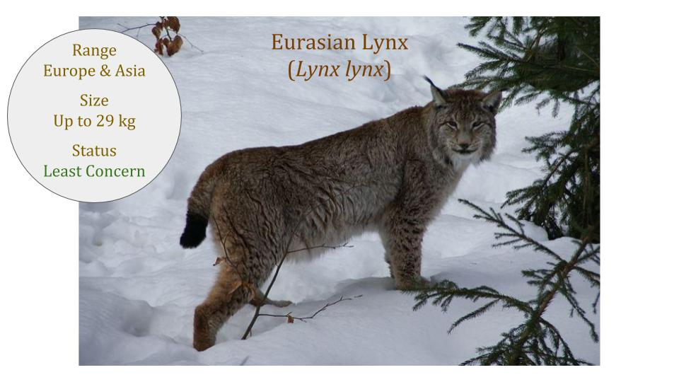

**Figure 1:** A picture of an Eurasian lynx taken in a snowy environment and some basic informations are shown.<sup>[1](https://www.wildcatfamily.com/lynx-lineage/)</sup>

As indicated in Figure 1, the status of the Eurasian lynx is indicated as least concern based on the website of the International Union for Conservation of Nature’s (IUCN) threatened species red list, although some other organizations describe it as endangered<sup>[3](https://www.iucnredlist.org/species/12519/121707666#geographic-range)</sup>. The evaluations of regional organizations should also be taken into account, as they are likely to be regionally endangered as they spread over a wide area.In addition to the distribution map of the species on the IUCN site, distribution map data can also be downloaded as a shape file, thus providing a suitable resource for use in ecological niche modeling studies. The Global Biodiversity Advisory Facility (GBIF) provides researchers with the occurrence data, another important type of data for ENMs, with their coordinates. In order to make the occurrence data from GBIF meaningful according to the lineages, since there is no direct genomic study and there is no DNA data, they are differentiated according to the countries where clades were detected in previous studies, using the literature. Based on this information, firstly, occurrence data of lynx lynx species were obtained from the GBIF site and distribution range data from the IUCN site. Then, starting from the clade information taken from the article “Mitogenome Phylogeny Including Data from Additional Subspecies Provides New Insights into the Historical Biogeography of the Eurasian lynx (*Lynx lynx*) published by Deniz Mengüllüoğlu et al., and the occurrence data of subspecies from GBIF, A map was prepared using R. Lineage information of the lynx lynx species from the article is as shown in figure 2.

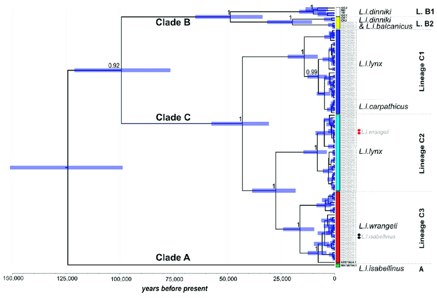

**Figure 2:** Three different main lineages of *lynx lynx* from past to present are shown. Also, clade b and clade c are also divided into clades within themselves.<sup>[2](https://www.researchgate.net/publication/353741006_Mitogenome_Phylogeny_Including_Data_from_Additional_Subspecies_Provides_New_Insights_into_the_Historical_Biogeography_of_the_Eurasian_lynx_Lynx_lynx)</sup>

Although there is countryCode information in the data sets obtained from GBIF, since there is no genetic lineage information, the information of the countries and subspecies of the clades in this article which are shown in the figure 3 was used.

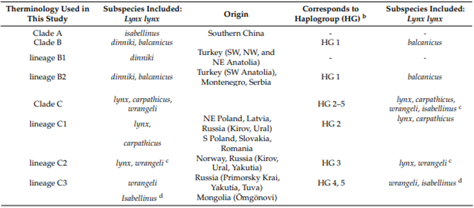

**Figure 3:** Properties of the lineages of the lynx lynx species is shown. <sup>[2](https://www.researchgate.net/publication/353741006_Mitogenome_Phylogeny_Including_Data_from_Additional_Subspecies_Provides_New_Insights_into_the_Historical_Biogeography_of_the_Eurasian_lynx_Lynx_lynx)</sup>

# Methods

In this project, current and future ecological niche models were prepared for the Eurasian lynx (*lynx lynx*) using the R Studio application. These projections were made using the BIOMOD2 package.

## Data collection and processing

The project started with the collection of the necessary occurrence and distribution map data, and these data were obtained from the websites of IUCN and GBIF organizations. Occurrence data from GBIF is excel files with .csv extension, while distribution map data from IUCN is shape file with .shp extension. No processing has been done for the distribution map data, it is already used as a reference. Some arrangements have been made for the occurrence data, the data has been framed and cleaned. Then, data were prepared based on country codes for 3 different clades, and a collective data of all clades was also prepared.

The distribution map of all clades was plotted using the clean and marked occurrence data according to the lineages obtained after the data processing and the same process was repeated only for the data belonging to clade b. After the distribution maps for all clades and clade b were prepared, bioclimatic data for current and future projections were collected and processed. Bioclimatic current and future data are taken from worldclim’s website and future data is MIROC-6 data of SSP370 scenario. Among these bioclimatic data from bio1 to bio19; bio1, bio6, bio11, and bio15 were used.

## Projections

After the necessary data were obtained, these data were formatted, modeled, ensembled, and finally projected with the codes written using the biomod2 package. Separate current and future range change projections were made for the data of all clades and data of clade b. In order to obtain these projections, first of all, GLM and GAM models and TSS and ROC binary methods were tested on the data of all clades. Model score evaluations were made for the models obtained and no significant difference was observed. However, GAM modeling and TSS binary method did not work due to few occurrence data while repeating the same operations with clade b, so all projections were made using GLM and ROC.

## Range Change Mapping

# Results

In this project, firstly, the occurrence data of Eurasian lynx was taken from GBIF and distribution map from IUCN, these data were processed and made usable. Then, SSP370 bioclimatic data of 2081-2100 period MIROC6 Global Climate Model (GCM) with 5 minutes spatial resolution were taken from WorldClim. After obtaining the data according to the lineages, the distribution map of all clades was plotted using the clean and marked occurrence data obtained after the data processing and it is shown in figure 4.

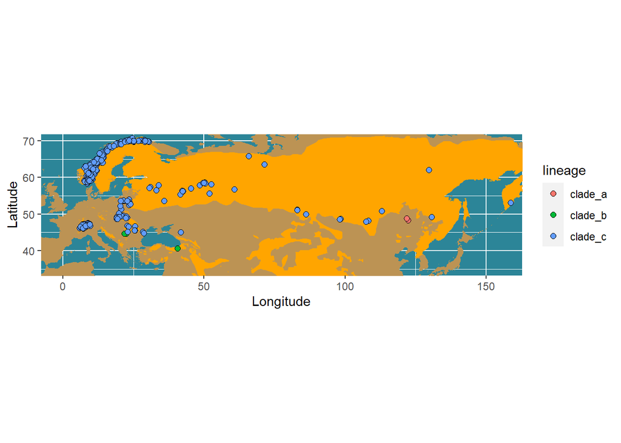

**Figure 4:** Distribution map of all *lynx lynx* clades prepared using GBIF occurrence and IUCN distribution data.

Then, the same process was repeated only for the data belonging to clade b, and the obtained clade b distribution map is shown in figure 5.

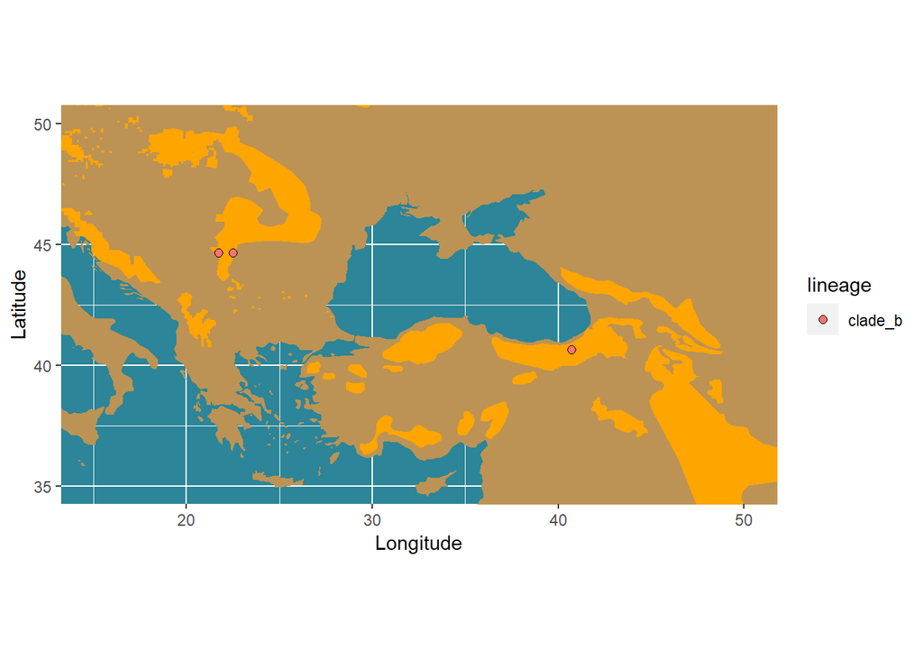

**Figure 5:** Distribution map of clade b of *lynx lynx* prepared using GBIF occurrence and IUCN distribution data.

## Current Projections

Then, using the biomod2 package, the current projections are formed using the current bioclimatic data for two different modeling lines prepared using the data of all clades and only the data of clade b were as shown in figure 6 and 7.

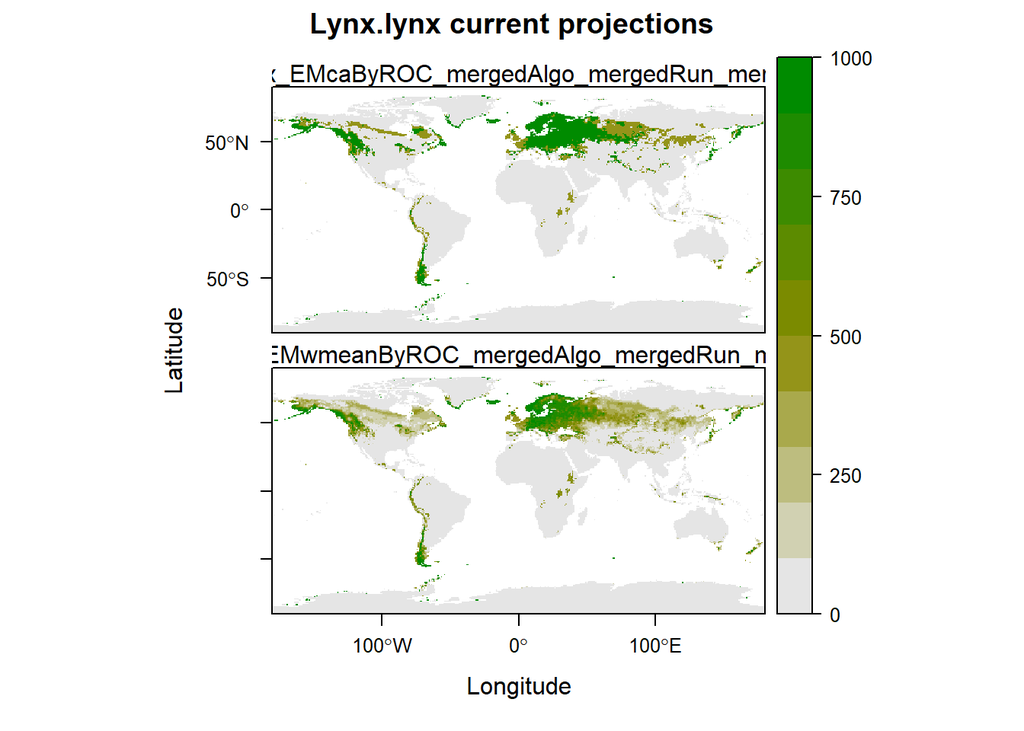

**Figure 6:** The current projection prepared for the data of all clades is shown. They are prepared with CA(Committe Averaging) and Wmean(Weighted Mean) calculations obtained by ROC binary method.

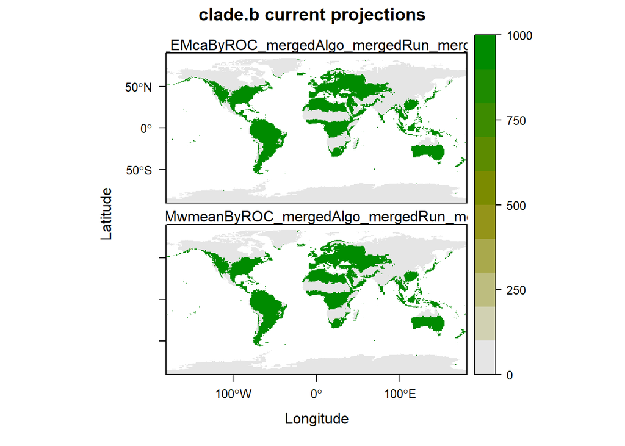

**Figure 7:** The current projection prepared for the data of clade b is shown.

## Future Projections

After the current projections, the future projections are formed using the future(2081-2100) SSP370 by MIROC6 bioclimatic data for two different modeling lines prepared using the data of all clades and only the data of clade b were as shown in figure 8 and 9.

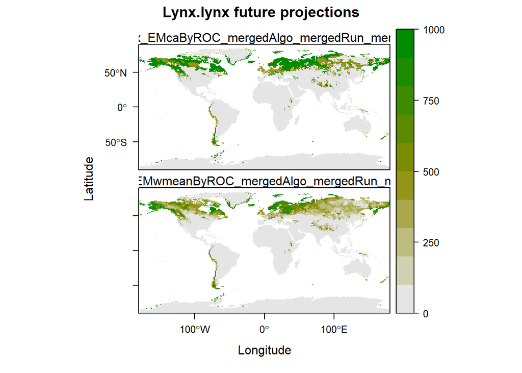

**Figure 8:** The future(2081-2100) projection prepared for the data of all clades is shown.

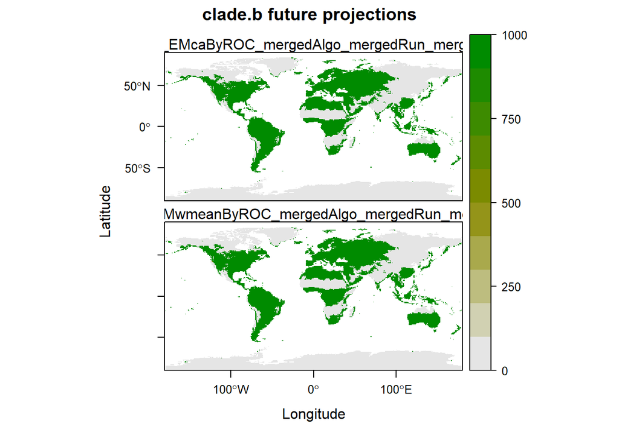

**Figure 9:** The future(2081-2100) projection prepared for the data of clade b is shown.